# The Tailor RNA-Seq Pipeline: a Tool for *De Novo* Disease Biomarker Identification

BIOL607 Final Project

Andrew Judell-Halfpenny

Fall Semester 2018

# Background

High-Throughput Sequencing is one of the most promising tools available to researchers united by the common-goals of personalized medicine. Identifying a unique transcriptional signature through comparative RNA-Seq analysis provides enables earlier detection, informs future drug design, and ultimately saves lives. The first step towards providing targeted interventions for genetic diseases is identifying the genomic features common to a particular phenotype. . But identifying clinically informative features from the massive sequence libraries (~1-2 Tb) produced during one experiment exceed the capabilities of most personal computers and necessitates the use of a high-performance computing cluster (HPCC) with a standardized downstream analysis procedure. These circumstances create a skills-gap bottleneck that requires molecular biologists to develop new skill sets with extensive knowledge of computer programming and software engineering. This bottleneck is further exacerbated by the difficulty of identifying high-confidence biomarkers for a population from a small sample experiment with low statistical power. The Tailor Pipeline was designed to address these issues and facilitate biomarker discovery from comparative RNA-Seq analyses between two or more conditions.

# Introduction to the Tailor Pipeline

The Tailor pipeline was developed to perform comparative genomic analyses designed by UMass Boston’s Center for Personalized Cancer Therapy and Genomics Core. Tailor is optimized for use with the binary bcl data files produced by the Sequencing-by-Synthesis (SBS) protocol of an Illumina HiSeq 2500. In less than 72 hours, Tailor can analyze the ~ 1Tb of data produced during a single sequencing run.

[figure not shown]

The Tailor RNA-Seq analysis pipeline is an end-to-end tool-suite that produces a set of biomarkers from the significant differential expression between two or more conditions. Tailor extends and simplifies the Tophat-Cufflinks tool-suite for RNA-Seq library preparation in order to perform comparative gene expression analyses and visualize significant differences in the gene expression profiles between two or more conditions. The pipeline provides an automated workflow that facilitates resource requests over a high performance computing cluster through multi-step, in-parallel, computational “jobs” submitted to either LSF or SGE job-schedulers. The output from each previous step is automatically input to the next step which is initiated with a simple two-word command (“tailor bcl2fastq,” “tailor fastqc,” “tailor trimgalore”) from a command-line interface.

To perform Tailor’s differential expression analysis, the user must provide a sample sheet that maps the names of the input (bcl) files to the human readable names of the samples from each group or condition. Tailor can only quantify expression of annotated gene models that index a sequenced genome. Tailor includes a secondary suite of tools for genome indexing and gene-model building for analyses with non-model organisms. Tailor’s workflow can be customized via modification of the provided settings configuration file. This feature enables the user to initiate the workflow from any step of the pipeline and utilizing most standard RNA-Seq file formats (fastq.gz, sam, bam, gtf, gff, cxb, and fg.gz). Several pre-configured settings files are included with Tailor to provide different levels of de-novo feature discovery. The default workflow does not perform any novel feature discovery and is the simplest workflow. The genome-guided, de novo workflow uses gene-model annotations to guid isoform discovery. The fully de novo workflow is operated without gene models and is the most computationally intensive.

# Research Design

The Tailor pipeline begins with human readable file conversion as well read de-multiplexing via **bcl2fastq**, software designed by Illumina HiSeq data. The next step in the pipeline is **FastQC** quality control inspection of the sequence data in order to check for over-represented sequences, anomalous features, and phred quality scores (1). The paired end reads must be parsed by **Trim-galore** in order to identify the unique adapter sequence that ligated the reads from a particular sample to the bottom of the flow-cell (2). After adapter trimming, the sequence libraries, and can be mapped to the reference genome/transcriptome by **Tophat**, a splice aware mapper. (3). After read-mapping, the transcripts are and the sequences of the gene models are assembled by Cufflinks into de-Bruijn graphs (4). **Cufflinks** determines how to assemble the transcripts and the gene structure Bipartite matching isoforms into minimum-spanning-trees (mst) that account for the distribution of reads from a gene. After the transcripts of each sample are assembled into a gene transfer format file, they are compared to the reference annotation by **Cuffmerge** (5). The new gene models and the mapped bam files from the Tophat step are input to **Cuffquant** for gene expression quantification (6). The gene models and the gene expression files are input to **Cuffdiff** for comparative differential expression analysis (7). Biomarker candidates are identified by Cuffdiff from FDR correcting the p-values associated with the test-statistic of means tests of each conditions distribution expression values for each gene . Tailor provides a set of secondary analysis tools that produce visually digestible summations of the salient features common among the samples of a particular phenotype. Tailor’s analysis workflow enables biologists to extract RNA in a noninvasive manner from blood or urine and identify the causal genetic phenomena associated with the presentation of a diseased phenotype.

# Results/Summary of the Investigation:

In a recent comparative analysis between 9 males diagnosed with non-cancerous, fibrosis-associated, lower urinary tract syndrome (LUTS) and 9 canonically healthy males serving as a control group, Tailor analyzed ~1 Tb of RNA-Seq data over the course of 31 hours. The samples were provided by 9 males diagnosed with non-cancerous fibrosis-associated lower urinary tract syndrome and 9 males serving as an archetypal control group. RNA was extracted, ligated with sample-specific adapters, and multiplexed to reduce flow-cell lane bias. The Tailor pipeline workflow began with a demultiplexing step and then proceeded to a quality control step with FastQC. before trimming of the sample-specific adapters. At this point in the pipeline, sequence library preparation has completed and the reads are mapped to a reference genome/transcriptome. Tailor performed alignment to the hg38 Homo sapiens reference genome with the Tophat tool-suite yielding an average overall unique mapping rate of 94.0% with a minimum overall mapping rate of 82.3%. Average concordant pair-mapping rate to the hg38 genome was 82.2% with a minimum per-sample concordant pair-mapping rate of 66.8%. Tailor assembled transcripts for 32245 genes, 92397 isoforms, 54249 coding sequences. Tailor detected sufficient expression levels to determine statistical significance during differential expression analysis for 25171 coding sequences, 15118 genes, 32316 isoforms. Of the features with adequate expression levels, 115 coding sequences, 370 genes, and 251 isoforms were identified as significantly differentially expressed. Leave-one-out cross validation produced 18 sets of significantly differentially expressed genes with similar totals for the significant differential expression of sed gene set from each iteration. The average total number of significantly differentially expressed genes was 225. Cross-validation whittled the final high-confidence biomarker set down to 27 genes that were consistently differentially expressed independent from the influences of single samples. Gene ontology analysis identified significant enrichment for 33 molecular functions, 34 cellular components, and 102 biological processes between the groups.

# Extended Analysis Section:

In order to remove any spurious calls that Tailor may have produced, a second differential expression analysis was performed. Performing repeated analyses with other commonly used software packages provides the added benefit of an accuracy quantification estimate for Tailor’s biomarker calls. The additional *in silico prediction* refinement analysis is being performed in the R statistical programming environment with several other **Bioconductor** packages for differential expression analysis (8). Raw read counts extracted from Tailor’s SQLite database backend will serve as input for **EdgeR** and **Limma** (9,10). Features that are consistently identified by each of the analysis methods will be interpreted as true positives. Features that are not consistently identified by each method will be interpreted as spurious calls and omitted from the final biomarker set. The final set of biomarker features will be in-vivo validated by either nanoDrop sequencing or qtPCR to determine their efficacy as a test for new patients suffereing from the disease.

```r
cuff<- readCufflinks(dir='/home/drew/umb_triley/urine1/cuffdiff_results_hg38_default/LUTS-over-CTRL/',genome="/home/drew/umb_triley/Reference-Genomes-and-Gene-Sets/Reference-Genomes/Human/UCSC_hg38/genome.fa",gtfFile='/home/drew/umb_triley/Reference-Genomes-and-Gene-Sets/Reference-Genomes/Human/UCSC_hg38/genes.gtf', rebuild=F)
cuff
```

```
## CuffSet instance with:
##   2 samples
##   26372 genes
##   56891 isoforms
##   36510 TSS
##   38679 CDS
##   26225 promoters
##   36510 splicing
##   19164 relCDS
```

```r
replicates.info<-cummeRbund::replicates(cuff)
replicates.info
```

```
##                                                           file sample_name
## 1   cuffquant_results_hg38_default/Sample_3_out/abundances.cxb        CTRL
## 2   cuffquant_results_hg38_default/Sample_5_out/abundances.cxb        CTRL
## 3   cuffquant_results_hg38_default/Sample_7_out/abundances.cxb        CTRL
## 4   cuffquant_results_hg38_default/Sample_9_out/abundances.cxb        CTRL
## 5  cuffquant_results_hg38_default/Sample_11_out/abundances.cxb        CTRL
## 6  cuffquant_results_hg38_default/Sample_13_out/abundances.cxb        CTRL
## 7  cuffquant_results_hg38_default/Sample_15_out/abundances.cxb        CTRL
## 8  cuffquant_results_hg38_default/Sample_17_out/abundances.cxb        CTRL
## 9  cuffquant_results_hg38_default/Sample_19_out/abundances.cxb        CTRL
## 10  cuffquant_results_hg38_default/Sample_4_out/abundances.cxb        LUTS
## 11  cuffquant_results_hg38_default/Sample_6_out/abundances.cxb        LUTS
## 12  cuffquant_results_hg38_default/Sample_8_out/abundances.cxb        LUTS
## 13 cuffquant_results_hg38_default/Sample_10_out/abundances.cxb        LUTS
## 14 cuffquant_results_hg38_default/Sample_12_out/abundances.cxb        LUTS
```

[output cut: 23 more lines]

```r
groups<-replicates.info$sample_name
samples<-replicates.info$rep_name
conditions<-as.factor(groups)
conditions
```

```
##  [1] CTRL CTRL CTRL CTRL CTRL CTRL CTRL CTRL CTRL LUTS LUTS LUTS LUTS LUTS
## [15] LUTS LUTS LUTS LUTS
## Levels: CTRL LUTS
```

```r
samples
```

```
##  [1] "CTRL_0" "CTRL_1" "CTRL_2" "CTRL_3" "CTRL_4" "CTRL_5" "CTRL_6"
##  [8] "CTRL_7" "CTRL_8" "LUTS_0" "LUTS_1" "LUTS_2" "LUTS_3" "LUTS_4"
## [15] "LUTS_5" "LUTS_6" "LUTS_7" "LUTS_8"
```

```r
groups
```

```
##  [1] "CTRL" "CTRL" "CTRL" "CTRL" "CTRL" "CTRL" "CTRL" "CTRL" "CTRL" "LUTS"
## [11] "LUTS" "LUTS" "LUTS" "LUTS" "LUTS" "LUTS" "LUTS" "LUTS"
```

```r
under=groups[1]
over=groups[((length(groups)/2)+1)]
over;under
```

```
## [1] "LUTS"
```

```
## [1] "CTRL"
```

```r
# design matrix
design <- model.matrix(~0 + groups, data=replicates.info)
colnames(design) <- levels(conditions)
row.names(design) <- samples
design
```

```
##        CTRL LUTS
## CTRL_0    1    0
## CTRL_1    1    0
## CTRL_2    1    0
## CTRL_3    1    0
## CTRL_4    1    0
## CTRL_5    1    0
## CTRL_6    1    0
## CTRL_7    1    0
## CTRL_8    1    0
## LUTS_0    0    1
## LUTS_1    0    1
## LUTS_2    0    1
## LUTS_3    0    1
## LUTS_4    0    1
## LUTS_5    0    1
## LUTS_6    0    1
## LUTS_7    0    1
## LUTS_8    0    1
## attr(,"assign")
## [1] 1 1
## attr(,"contrasts")
## attr(,"contrasts")$groups
## [1] "contr.treatment"
```

```r
# contrast matrix
contr.matrix <- makeContrasts(LUTS - CTRL, CTRL - LUTS,
                              levels = colnames(design))
contr.matrix
```

```
##       Contrasts
## Levels LUTS - CTRL CTRL - LUTS
##   CTRL          -1           1
##   LUTS           1          -1
```

```r
# gene expr data
#all_exp.df<-diffTable(cummeRbund::genes(cuff))
g.cnt.matrix<-repCountMatrix(cummeRbund::genes(cuff))
# factors for conditions
under.group<-grep(pattern=under, colnames(g.cnt.matrix))
over.group<-grep(pattern=over, colnames(g.cnt.matrix))

# Library Sizes
colSums( g.cnt.matrix )
```

```
##   CTRL_0   CTRL_1   CTRL_2   CTRL_3   CTRL_4   CTRL_5   CTRL_6   CTRL_7
## 11882040 12511447 18492880 11337240 11593500 12244492 15549069 11447407
##   CTRL_8   LUTS_0   LUTS_1   LUTS_2   LUTS_3   LUTS_4   LUTS_5   LUTS_6
## 12015349 11384100 12668196 14971358 13717578 16030915 11100257 16226846
##   LUTS_7   LUTS_8
## 10987524 18909776
```

```r
# Library Sizes in millions of reads
colSums( g.cnt.matrix ) / 1e06
```

```
##   CTRL_0   CTRL_1   CTRL_2   CTRL_3   CTRL_4   CTRL_5   CTRL_6   CTRL_7
## 11.88204 12.51145 18.49288 11.33724 11.59350 12.24449 15.54907 11.44741
##   CTRL_8   LUTS_0   LUTS_1   LUTS_2   LUTS_3   LUTS_4   LUTS_5   LUTS_6
## 12.01535 11.38410 12.66820 14.97136 13.71758 16.03092 11.10026 16.22685
##   LUTS_7   LUTS_8
## 10.98752 18.90978
```

## Filtering and Normalizing Gene Expression Values

```r
norm.factors <- calcNormFactors(g.cnt.matrix, method = "TMM")
g.CPM.ma <- cpm(g.cnt.matrix, prior.count=1)
str(g.CPM.ma)
```

```
##  num [1:26372, 1:18] 0 0 0.0629 128.6665 0 ...
##  - attr(*, "dimnames")=List of 2
##   ..$ : chr [1:26372] "A1BG" "A1BG-AS1" "A1CF" "A2M" ...
##   ..$ : chr [1:18] "CTRL_0" "CTRL_1" "CTRL_2" "CTRL_3" ...
```

```r
g.LCPM.ma <- cpm(g.cnt.matrix, log=TRUE, prior.count=1)
str(g.LCPM.ma)
```

```
##  num [1:26372, 1:18] -3.76 -3.76 -2.87 7.01 -3.76 ...
##  - attr(*, "dimnames")=List of 2
##   ..$ : chr [1:26372] "A1BG" "A1BG-AS1" "A1CF" "A2M" ...
##   ..$ : chr [1:18] "CTRL_0" "CTRL_1" "CTRL_2" "CTRL_3" ...
```

```r
## filter genes with at less than 1 cpm in at least 9 samples
keep.exprs <- rowSums(g.LCPM.ma > 1) >= length(groups)/2
table(keep.exprs)
```

```
## keep.exprs
## FALSE  TRUE
## 15981 10391
```

```r
# Subset the rows of countdata to keep the more highly expressed genes
g.f.cnt.ma <- as.data.frame(g.LCPM.ma[keep.exprs,])
str(g.f.cnt.ma)
```

```
## 'data.frame':    10391 obs. of  18 variables:
##  $ CTRL_0: num  7.01 8.38 4.44 -3.76 2.2 ...
##  $ CTRL_1: num  7.72 8.73 2.64 4.21 2 ...
##  $ CTRL_2: num  -3.76 6.14 6.89 -3.76 -3.76 ...
##  $ CTRL_3: num  7.33 6.35 3.72 2.23 4.82 ...
##  $ CTRL_4: num  9.73 7.78 3.23 5.03 3.02 ...
##  $ CTRL_5: num  6.42 -2.76 -3.76 4.15 -2.76 ...
##  $ CTRL_6: num  6.57 8.79 6.57 -3.76 7.48 ...
##  $ CTRL_7: num  8.07 9.63 4.8 3.76 3.78 ...
##  $ CTRL_8: num  9.124 10.289 3.798 0.893 -2.344 ...
##  $ LUTS_0: num  8.38 6.48 -2.99 5.3 5.22 ...
##  $ LUTS_1: num  6.38 8.05 3.59 -3.76 4.39 ...
##  $ LUTS_2: num  6.09 9.42 -2.56 6.87 -1.91 ...
##  $ LUTS_3: num  5.683 9.804 0.613 -3.755 -3.755 ...
##  $ LUTS_4: num  6.31 10.13 -3.76 5.16 -3.76 ...
##  $ LUTS_5: num  9.45 5.23 2.76 4.34 4.24 ...
##  $ LUTS_6: num  -1.79 10.83 6.67 1.52 2.52 ...
##  $ LUTS_7: num  7.77 8.58 4.91 4.7 1.91 ...
##  $ LUTS_8: num  6.594 -1.458 -0.843 -3.755 1.618 ...
```

```r
# Test normality
norm.1st.group<-apply(g.f.cnt.ma[1:round(nrow(g.f.cnt.ma)/3),], 1, function(x) shapiro.test(x)$p.value)
sum(norm.1st.group < 0.05)
```

```
## [1] 2775
```

```r
norm.2nd.group<-apply(g.f.cnt.ma[c(round(nrow(g.f.cnt.ma)/3):c(2*round(nrow(g.f.cnt.ma)/3))),], 1, function(x) shapiro.test(x)$p.value)
sum(norm.2nd.group < 0.05)
```

```
## [1] 2697
```

```r
norm.3rd.group<-apply(g.f.cnt.ma[c(((2*round(nrow(g.f.cnt.ma)/3))+1):nrow(g.f.cnt.ma)),], 1, function(x) shapiro.test(x)$p.value)
sum(norm.3rd.group < 0.05)
```

```
## [1] 2760
```

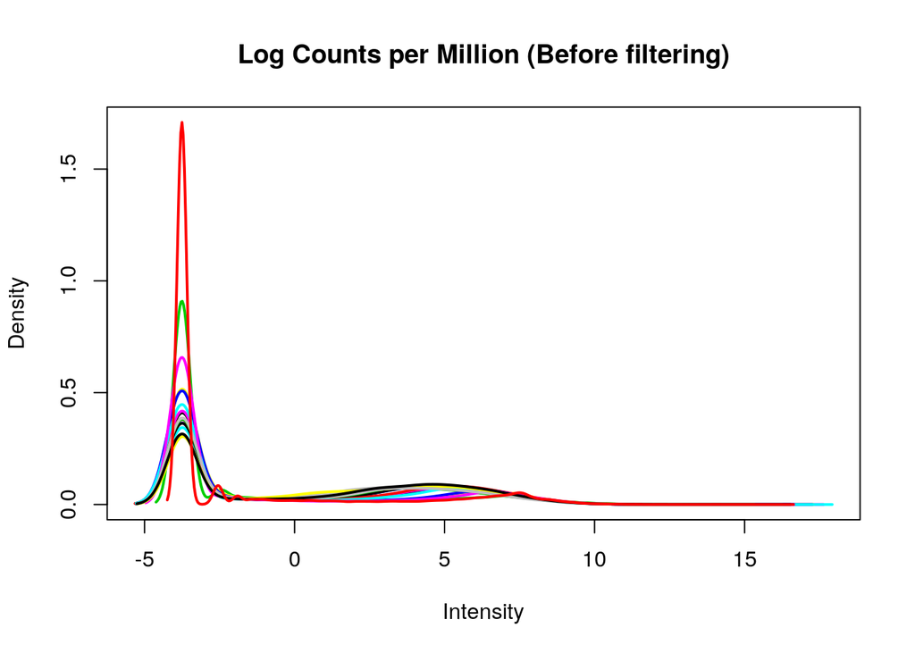

```r
# Visualize distribution of gene expression levels
plotDensities(g.LCPM.ma, legend = FALSE, main = "Log Counts per Million (Before filtering)")
```

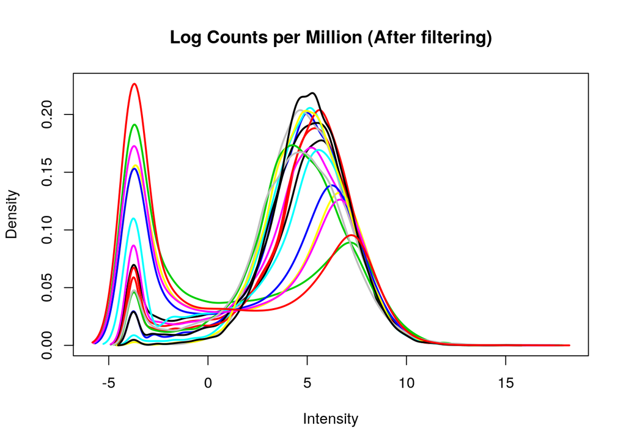

```r
# Visualize distribution of gene expression levels
plotDensities(g.f.cnt.ma, legend = FALSE, main = "Log Counts per Million (After filtering)")
```

```r
# visualize coefficient of variation
```

# Limma Linear Models

Limma was used to fit a linear model for each gene that modeled the gene expression of the control group as the predictor variable and the gene expression of the luts patient group as the response variable. A Shapiro-Wilks test of the data demonstrates that gene expression values is not normally distributed and therefor is not feasibly modeled with an ordinary least squares (OLS) regression. The count data additionally exhibits heteroscedascity of the variance that is not independent of the mean. To accommodate this mean-variance relationship a negative binomial distribution was used to model the count data assumes a quadratic relationship between the mean variance. This relationship results from a combination of technical variation in the sequencing experiment and biological variation amongst the replicated samples from each group. The count data is modeled with the voom Bioconductor package as a negative binomial distribution with the precision weights being easily calculated the voom normalization command. The voom output demonstrates a reduction in the trend between the means and variances. However there is a problematic trend between the model’s residual variances and the average expression values. To eliminate this relationship empirical Bayes moderation is performed by estimating gene-wise variability across the entire dataset. The qqplot of the moderated t-statistic suggests that the model fit is apppropriate.

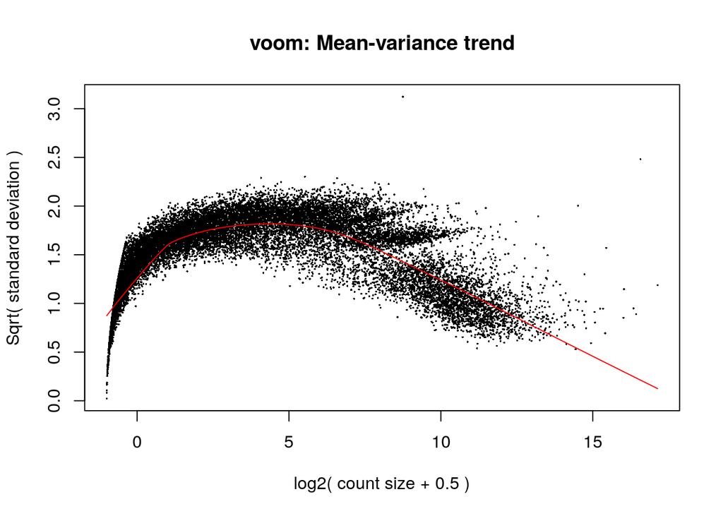

```r
dgel<- DGEList(counts=g.cnt.matrix, group=factor(groups))
dge.norm <- calcNormFactors(dgel)
log2.cpm <- voom(dge.norm,design,plot=TRUE,normalize.method="quantile")
```

```r
log2.cpm
```

[output not shown]

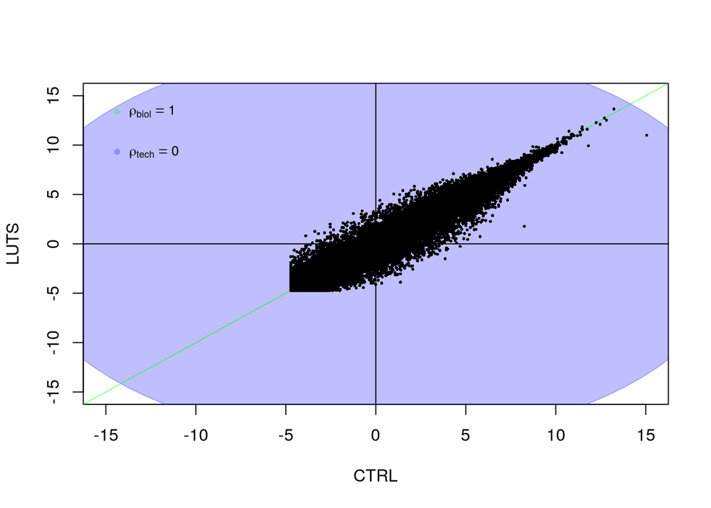

```r
fit.lm <- lmFit(log2.cpm,design)
biol.cor<-genas(fit.lm, coef=c(1,2), plot=TRUE, subset="all",alpha=0.25)
```

```r
biol.cor
```

```
## $technical.correlation
## [1] 0
##
## $covariance.matrix
##          [,1]     [,2]
## [1,] 112324.8 112319.7
## [2,] 112319.7 112315.3
##
## $biological.correlation
## [1] 0.9999975
##
## $deviance
## [1] 304895.5
##
## $p.value
## [1] 0
##
## $n
## [1] 26372
```

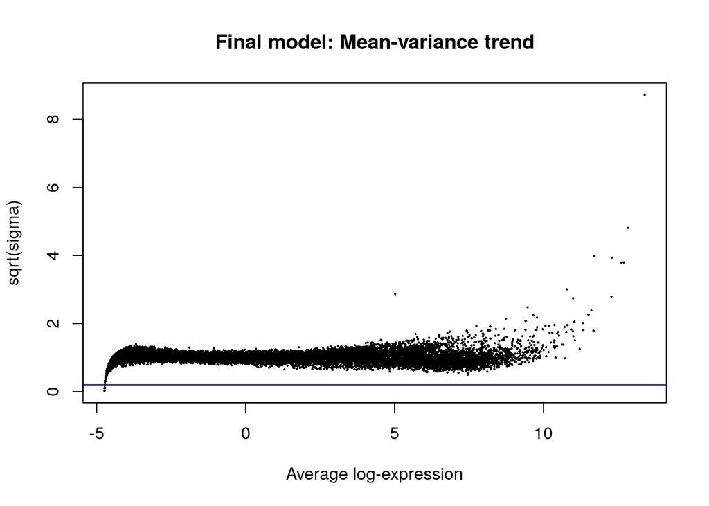

```r
#biol.cor$deviance
contrast.matrix <- makeContrasts(CTRL-LUTS,levels=design)
fit2 <- contrasts.fit(fit.lm, contrast.matrix)
#  Estimate biological correlation between the logFC profiles
#  for A-vs-Ctrl and B-vs-Ctrl
fit.bayes <- eBayes(fit2)
plotSA(fit.bayes, main="Final model: Mean-variance trend")
```

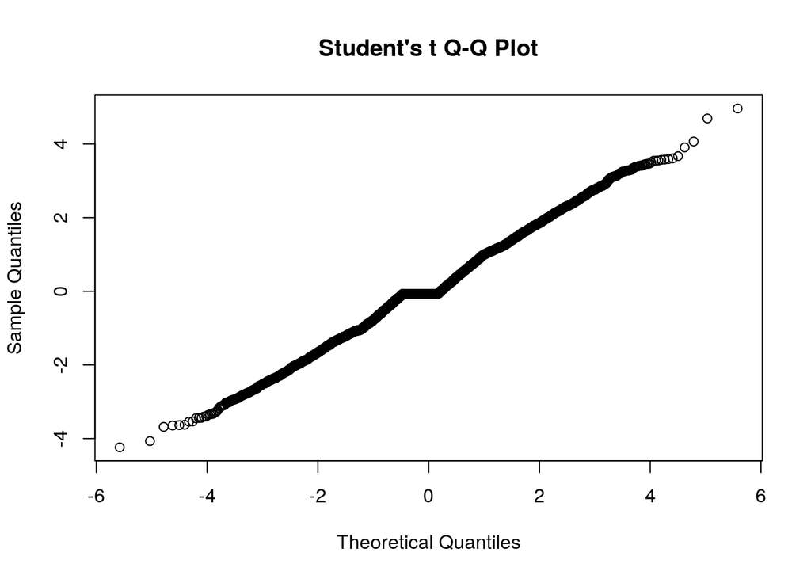

```r
# Q-Q plot of moderated t-statistics
qqt(fit.bayes$t[,1],df=fit.bayes$df.residual+fit.bayes$df.prior)
```

```r
# Fold-change thresholding
tfit <- treat(fit.bayes, lfc = 1)
tfit
```

[output not shown]

[output cut: 55 more lines]

```
##   A1CF       0.8692200
##   A2M        0.9284633
##   A2M-AS1    0.9161724
## 26367 more rows ...
##
## $F
## [1] 0.77596142 1.29678160 0.04234256 0.01133734 3.93806734
## 26367 more elements ...
##
## $F.p.value
## [1] 0.3910979 0.2711531 0.8394992 0.9164947 0.0641855
## 26367 more elements ...
##
## $treat.lfc
## [1] 1
```

```r
sig.tfit<-subset(tfit$p.value, (tfit$p.value < 0.05))
length(sig.tfit)
```

```
## [1] 188
```

```r
# Classic Approach without filtering
dgeObj <- DGEList(counts=g.cnt.matrix, group=groups)
dgeObj
```

```
## An object of class "DGEList"
## $counts
##               CTRL_0   CTRL_1 CTRL_2  CTRL_3  CTRL_4  CTRL_5  CTRL_6
## A1BG        0.000000    0.000      0    0.00    0.00    0.00    0.00
## A1BG-AS1    0.000000    0.000      0    0.00    0.00    0.00    0.00
## A1CF        0.747955  415.118      0    0.00    0.00    0.00    0.00
## A2M      1528.820000 2628.850      0 1822.81 9870.74 1050.92 1473.34
## A2M-AS1     0.000000    0.000      0    0.00    0.00    0.00    0.00
##              CTRL_7    CTRL_8     LUTS_0  LUTS_1 LUTS_2  LUTS_3    LUTS_4
## A1BG        0.00000    0.0000    0.00000    0.00    0.0   0.000    0.0000
## A1BG-AS1    7.14763    0.0000    0.00000    0.00    0.0   0.000    0.0000
## A1CF        0.00000   84.2029    0.00000    0.00    0.0   0.000   34.6153
## A2M      3078.10000 6705.2100 3796.59000 1052.94 1021.8 703.598 1268.0100
## A2M-AS1     0.00000    0.0000    2.34575    0.00    0.0   0.000    0.0000
##               LUTS_5  LUTS_6    LUTS_7    LUTS_8
## A1BG        0.212403 0.00000    0.0000    0.0000
## A1BG-AS1   22.727100 0.00000   14.9598    0.0000
## A1CF        1.486820 1.39289   22.4397   20.1034
## A2M      7780.520000 3.48224 2403.1800 1825.7500
## A2M-AS1     3.398440 0.00000   35.2623    0.0000
## 26367 more rows ...
##
## $samples
##        group lib.size norm.factors
## CTRL_0  CTRL 11882040            1
## CTRL_1  CTRL 12511447            1
## CTRL_2  CTRL 18492880            1
## CTRL_3  CTRL 11337240            1
## CTRL_4  CTRL 11593500            1
## 13 more rows ...
```

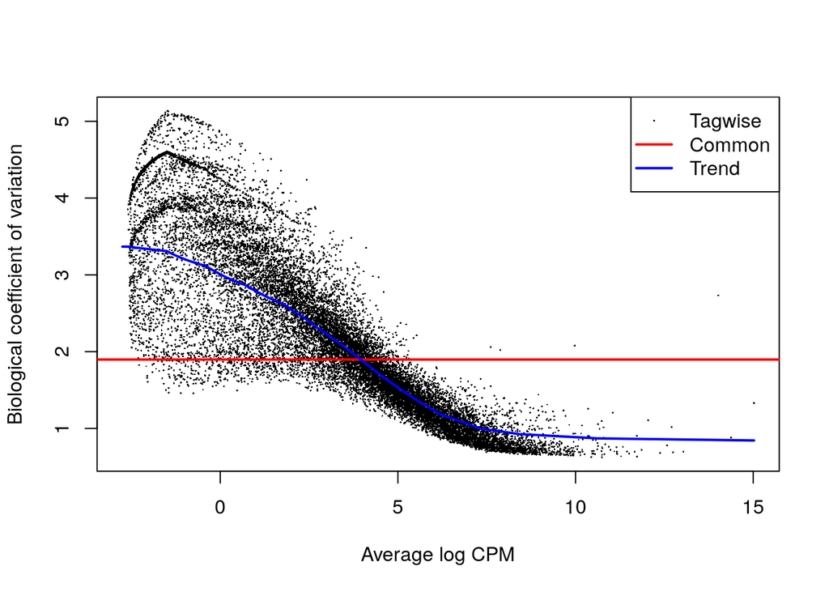

```r
# contrast matrix
contr.matrix <- makeContrasts(lutsVSctrl = CTRL - LUTS,
                               levels = design)
disp <- estimateDisp(dgeObj,design)
plotBCV(disp)
```

```r
levels(disp$samples$group)
```

```
## [1] "CTRL" "LUTS"
```

```r
et<-exactTest(disp)
topTags(et)
```

```
## Comparison of groups:  LUTS-CTRL
##               logFC   logCPM       PValue       FDR
## HBA2       8.599486 7.878551 1.568081e-05 0.4135344
## HBA1       8.335873 7.612371 3.299531e-05 0.4350761
## PBX4      10.030161 3.183811 8.718660e-05 0.7664284
## RGPD1     11.221120 3.488442 2.762253e-04 1.0000000
## SHC4     -10.258485 3.160191 3.690233e-04 1.0000000
## WNT3      -8.965952 2.453393 4.462342e-04 1.0000000
## EMX1      10.364495 2.643086 4.964770e-04 1.0000000
## APBA1      5.348067 4.434419 5.890971e-04 1.0000000
## DLX6-AS1  -7.361696 3.368980 5.991338e-04 1.0000000
## CCER2    -11.644965 3.904018 6.040153e-04 1.0000000
```

```r
o.sig.not.filt <- subset(et$table, (PValue < 0.05))
o.sig.not.filt
```

```
##                            logFC       logCPM       PValue
## AAMDC                  -3.900981  4.263833381 9.915356e-03
## ABCA13                  4.020495  2.965995502 7.731021e-03
## ABCD2                   9.340473  1.654242905 4.993790e-03
## ACRC                   -5.250258  2.252052633 2.080973e-02
## ADAMTS14                7.440278  0.721886675 3.774804e-02
## ADAMTSL1               -7.708683  0.150462532 3.786116e-02
## ADCY1                   3.157938  0.736169162 3.976260e-02
## ADCYAP1                 8.810730  1.153778619 2.029967e-02
## ADGRB3                 -6.698060 -0.683569992 3.913126e-02
## ADGRD1                 -6.196637  1.121770945 4.343420e-02
## ADRA2C                 -7.520680 -0.010759843 4.856543e-02
## AIMP2                   6.245902 -0.448523568 3.610850e-02
## AKR1D1                  4.540609 -0.118400115 3.600612e-02
## ALAS2                   9.839093  2.132561164 1.350029e-02
## ALB                     4.642113  4.032961330 2.335673e-02
## ALG1                    2.410693  3.915769583 4.910714e-02
## ALOX12P2               -6.076693  0.704168153 2.221702e-02
## ANK2                    5.687354  3.057715924 1.982651e-02
## ANKLE1                 -2.403519  2.959851981 4.043185e-02
## ANKRD33                 8.877816  1.214951533 1.557566e-02
## ANKRD34A                6.527635  3.127656148 4.752177e-03
## ANKS4B                 -3.580690  2.617475370 3.392796e-02
## ANKZF1                 -2.407754  4.696521809 3.105382e-02
## ANXA10                  8.269573  0.656984405 2.978571e-02
## ANXA8                   9.425809  1.735090450 2.036920e-02
## ANXA8L1                 9.468672  1.776104761 1.968242e-02
## APBA1                   5.348067  4.434419424 5.890971e-04
## APELA                  -7.872320  0.866544103 6.410237e-03
## APITD1-CORT             7.426938  0.616901417 2.393220e-02
## APOA1-AS               -7.758188  0.193817480 3.590576e-02
## AQP7                   -7.437457 -0.082816138 4.519281e-02
## ARIH2OS                -3.397249  1.088107316 1.548293e-02
## ASAP3                   6.593267  2.783469350 9.546302e-03
## ASB16                   5.848621  1.754635288 2.863419e-03
## ATAT1                  -2.992393  3.208482533 4.864439e-02
## ATP6V1E2                9.115715  1.922795243 2.712459e-03
## B4GAT1                  6.817121  0.021059306 1.861334e-02
## BACE1-AS               -4.901075  1.729481969 1.223292e-02
## BAGE3                   9.241856  1.564706107 1.152788e-02
```

[output cut: 536 more lines]

```
## ZNF461                 -3.509795  2.003909978 1.758337e-02
## ZNF462                  2.803886  3.938875072 3.286820e-02
## ZNF503-AS1              5.813003  3.117990972 2.762571e-03
## ZNF507                  2.610554  4.320773304 4.402827e-02
## ZNF556                 -4.543172  1.126667912 3.546322e-02
## ZNF559-ZNF177          -5.805256 -1.318186958 3.616385e-02
## ZNF568                  3.126159  3.250386658 4.592277e-02
## ZNF587B                -2.735254  3.208865347 4.910425e-02
## ZNF610                  5.399023  2.638584444 2.825218e-02
## ZNF674                  3.062365  2.182229520 2.936445e-02
## ZNF727                  5.489063  1.206479780 4.765031e-02
## ZNF883                 -8.963997  1.295042759 5.081341e-03
## ZNRD1-AS1              -6.896972 -0.042878933 4.183140e-02
## ZNRF2P1                -5.719087 -0.738838474 4.109530e-02
## ZSWIM5                  6.454790 -0.867821519 2.378781e-02
```

```r
# Classic Approach after filtering
logcounts <- cpm(dgeObj,log=TRUE,prior.count=1)
str(logcounts)
```

```
##  num [1:26372, 1:18] -3.76 -3.76 -2.87 7.01 -3.76 ...
##  - attr(*, "dimnames")=List of 2
##   ..$ : chr [1:26372] "A1BG" "A1BG-AS1" "A1CF" "A2M" ...
##   ..$ : chr [1:18] "CTRL_0" "CTRL_1" "CTRL_2" "CTRL_3" ...
```

```r
## Identify genes with at least 0.5 cpm in at least 9 samples
keep.exprs <- rowSums(logcounts > 2) >= length(groups)/2
table(keep.exprs)
```

```
## keep.exprs
## FALSE  TRUE
## 16826  9546
```

```r
# Subset the rows of countdata to keep the more highly expressed genes
g.f.cnt.ma <- g.cnt.matrix[keep.exprs,]
DGEobj.f=DGEList(g.f.cnt.ma,group=groups)
f.disp <- estimateDisp(DGEobj.f,design)
# fisher exact test
exactTst <- exactTest(f.disp)
o.sig.after.filt <- subset(exactTst$table, (PValue < 0.05))
o.sig.after.filt
```

```
##                  logFC    logCPM      PValue
## ALG1          2.411890  3.955323 0.038369961
## ANKZF1       -2.406472  4.735978 0.027289605
## ARHGAP11A     2.139237  4.342582 0.048462900
## ATAT1        -3.005012  3.257273 0.031539039
## BZW2          3.399074  4.286421 0.025169332
## C1orf216      2.273856  4.723364 0.038446764
## CALCOCO1      1.421269  7.043079 0.045865846
## CAMKK1       -2.709563  5.549718 0.026648231
## CCL5          2.185632  4.395951 0.028928283
## CD209        -2.218655  6.186519 0.031122553
## CDC23         3.082806  4.968643 0.032374213
## CENPC         2.556051  5.277060 0.006507345
## COA7         -2.231717  4.720291 0.035757948
## DBT          -1.802927  6.573451 0.014904266
## EIF5B        -1.358877  7.150056 0.015144114
## EMX2          2.551816  3.565190 0.028303505
## FAM213A       2.103176  5.368532 0.015307551
## FLVCR1        2.225742  4.494358 0.024070103
## FRAT1         2.613630  4.718491 0.028654318
## FRMD6        -2.922773  3.394498 0.048454407
## GPR180       -3.027910  3.706076 0.016477628
## GPR37L1       2.227364  4.252982 0.020320486
## HBB           5.034840 10.017600 0.007256275
## KLK4         -2.259527  5.715940 0.015171589
## LAMA3        -2.805172  4.532828 0.045894527
## LILRA1       -2.347404  5.282855 0.017165160
## LOC101929450  2.998215  4.365711 0.013286529
## MIR6723       1.763181  7.053480 0.007020964
## MSMO1        -2.842200  4.368721 0.031137688
## MST1P2        3.197617  4.530687 0.046498087
## MTRNR2L3      1.712252  5.060586 0.039527471
## MTRNR2L6      1.236717  8.024030 0.045818843
## MTRNR2L8      1.226761 14.419474 0.041926177
## MTRNR2L9      1.501136  7.957658 0.023489464
## MUT          -2.016118  5.698872 0.017440437
## NCDN         -2.280516  6.271203 0.009090345
## NMNAT2       -2.310785  5.153185 0.011792079
## NMT2          2.231100  4.301652 0.033977685
## OAS3         -1.354008  7.474273 0.023958819
```

[output cut: 18 more lines]

```
## TK1           3.134265  3.923085 0.046127941
## TMEM173       1.400460  5.731333 0.035523791
## TMEM55A      -3.691192  4.239975 0.033493383
## TMUB2        -1.659769  6.050317 0.040640522
## TP73-AS1      2.510356  5.040878 0.004198998
## TRAF3IP2-AS1 -2.843254  3.396828 0.017131504
## TRIM33        1.192527  6.988244 0.025982522
## TXNRD1        0.953300  9.606058 0.028056041
## UBE2J2       -3.260796  5.215713 0.003618204
## UCP2         -1.825932  7.134726 0.027055502
## UPK1A         2.722726  5.946244 0.029601793
## ZDHHC4       -2.436446  5.044772 0.031930211
## ZNF462        2.815043  3.982930 0.025712747
## ZNF507        2.615142  4.360549 0.040077316
## ZNF587B      -2.743439  3.256627 0.028833259
```

Due to the overdispersion evident in the data EdgeR was employed to model the count data with a quassipoisson model.

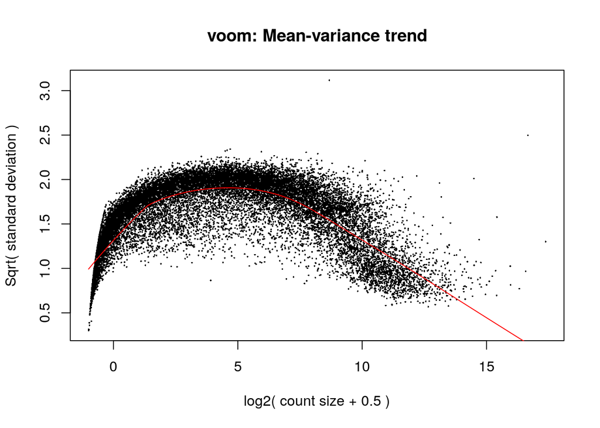

```r
dgel<- DGEList(counts=g.cnt.matrix, group=factor(groups))
dge.norm <- calcNormFactors(dgel)
log2.cpm <- voom(dge.norm,design,plot=TRUE)
```

```r
log2.cpm
```

[output not shown]

```r
fit.lm <- lmFit(log2.cpm,design)
summary(fit.lm)
```

```
##                  Length Class  Mode
## coefficients     52744  -none- numeric
## stdev.unscaled   52744  -none- numeric
## sigma            26372  -none- numeric
## df.residual      26372  -none- numeric
## cov.coefficients     4  -none- numeric
## pivot                2  -none- numeric
## rank                 1  -none- numeric
## Amean            26372  -none- numeric
## method               1  -none- character
## design              36  -none- numeric
```

```r
fit.bayes <- eBayes(fit.lm)
f.bayes.dt <- decideTests(fit.bayes)
summary(f.bayes.dt)
```

```
##         CTRL  LUTS
## Down   12763 12947
## NotSig  6811  7334
## Up      6798  6091
```

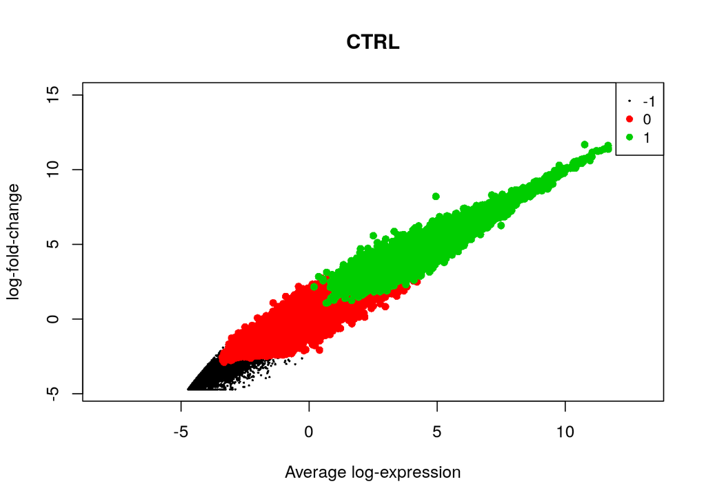

```r
tfit <- treat(fit.bayes, lfc = 2)
limma.res=topTable(tfit,coef=2,n=Inf,sort="p")
limma.res.sig<-subset(limma.res, (limma.res$adj.P.Val < 0.01) & (limma.res$logFC > 2))
plotMD(tfit, column = 1, status = f.bayes.dt[, 1], main = colnames(tfit)[1],
        xlim = c(-8, 13))
```

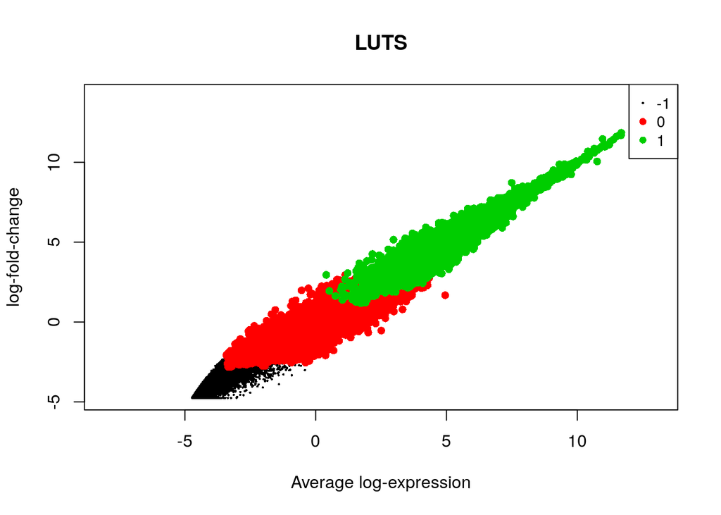

```r
plotMD(tfit, column = 2, status = f.bayes.dt[, 2], main = colnames(tfit)[2],
        xlim = c(-8, 13))
```

```r
de.common <- which(f.bayes.dt[, 1] != 0 & f.bayes.dt[, 2] != 0)
length(de.common)
```

```
## [1] 17548
```

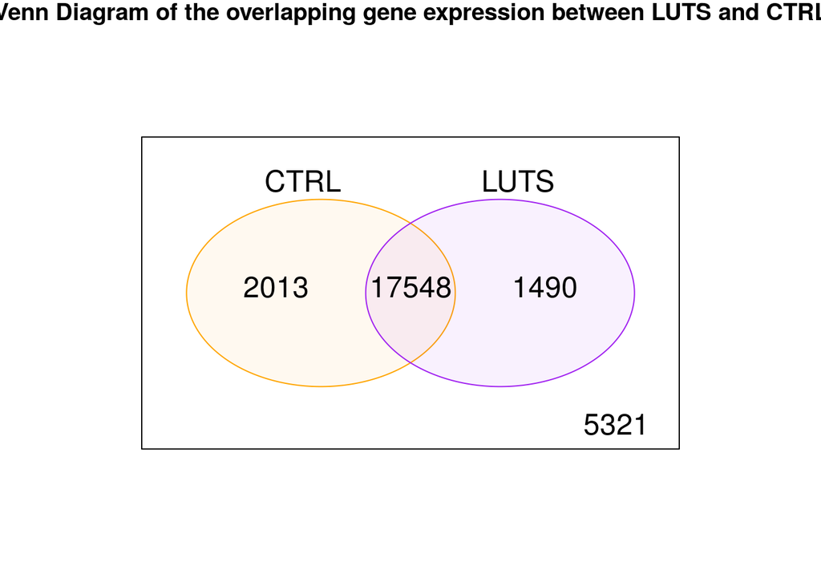

```r
 #head(tfit$genes$SYMBOL[de.common], n = 20)
vennDiagram(f.bayes.dt[, 1:2], circle.col = c("orange", "purple"),main=paste("Venn Diagram of the overlapping gene expression between", over, "and", under))
```

```r
lm<-lmFit(g.cnt.matrix,design)
fit.cnt <- eBayes(lmFit(g.cnt.matrix,design))
ebayes.dt <- decideTests(fit.cnt)
summary(ebayes.dt)
```

```
##         CTRL  LUTS
## Down       0     0
## NotSig 20624 20646
## Up      5748  5726
```

```r
tfit <- treat(fit.cnt, lfc = 1)
```

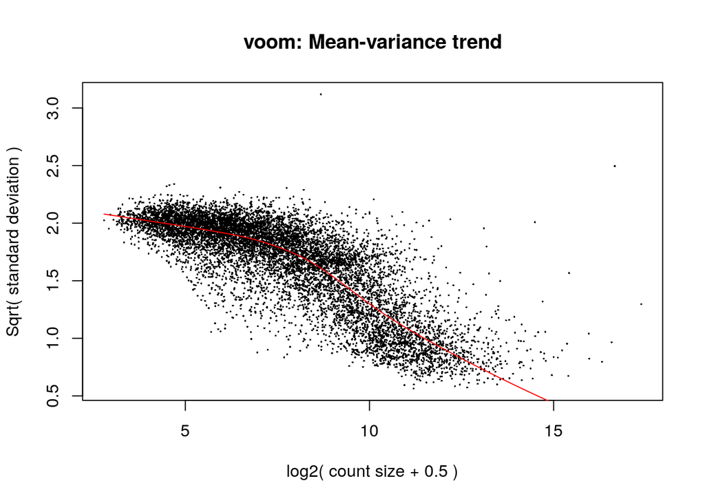

```r
limma.res.cnt=topTable(fit.cnt,coef=2,n=Inf,sort="p")
limma.res.cnt.sig<-subset(limma.res.cnt, (limma.res.cnt$adj.P.Val < 0.01) & (limma.res.cnt$logFC > 2))

# to account for sufficient effect size a minimal log-fold-change can be chosen
# isntead of using `eBayes`. Testing relative to a threshold
# dispersion
dgel<- DGEList(counts=g.f.cnt.ma, group=factor(groups))
dge.norm <- calcNormFactors(dgel)
log2.cpm <- voom(dge.norm,design,plot=TRUE)
```

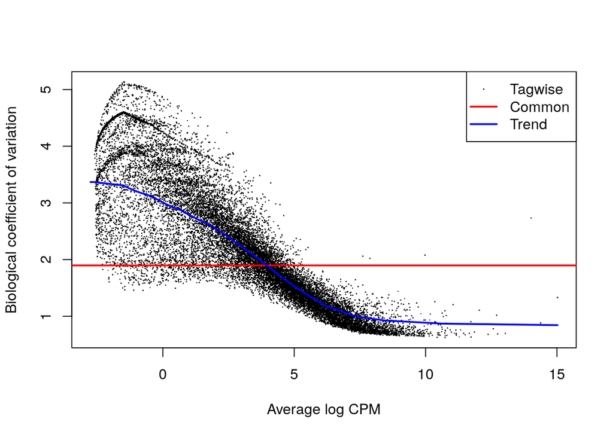

```r
fit.lm <- lmFit(log2.cpm,design)
fit.bayes <- eBayes(fit.lm)
f.bayes.dt <- decideTests(fit.bayes)
dgeObj.disp <- estimateDisp(dgeObj,design)
plotBCV(dgeObj.disp)
```

```r
# Fit the linear model
fit <- glmFit(dgeObj.disp, design)
glm.lrt <- glmLRT(fit, contrast=contr.matrix)
topTags(glm.lrt)
```

```
## Coefficient:  1*CTRL -1*LUTS
##             logFC   logCPM       LR       PValue       FDR
## HBA2    -8.599486 7.878551 20.11350 7.297968e-06 0.1924620
## HBA1    -8.335873 7.612371 18.63894 1.579609e-05 0.2082872
## PBX4   -10.030161 3.183811 17.84510 2.396352e-05 0.2106553
## RGPD1  -11.221120 3.488442 16.89025 3.960450e-05 0.2611125
## EMX1   -10.364495 2.643086 15.75938 7.193050e-05 0.3098164
## SHC4    10.258485 3.160191 15.75034 7.227492e-05 0.3098164
## CCER2   11.644965 3.904018 15.50619 8.223550e-05 0.3098164
## LMNTD2 -11.324057 3.586476 14.56755 1.352235e-04 0.3884145
## NPHS2  -10.097202 2.876069 14.40902 1.470962e-04 0.3884145
## SYCE2  -10.687247 2.959758 14.10841 1.725707e-04 0.3884145
```

```r
de2 <- decideTestsDGE(glm.lrt, adjust.method="BH", p.value = 0.05)
de2tags12 <- rownames(de2)[as.logical(de2)]
# overdispersion
dispers<-deviance(glm.lrt)/df.residual(glm.lrt)
over.disp<-dispers[which(dispers > 1)]
length(over.disp)
```

```
## [1] 8500
```

```r
not.over.disp<-dispers[which(dispers < 1)]
length(not.over.disp)
```

```
## [1] 17872
```

```r
# Fix overdisperion
q.fit <- glmFit(dgeObj.disp, design, family="quasipoisson")
head(coef(q.fit))
```

```
##                CTRL       LUTS
## A1BG     -18.497930 -18.305998
## A1BG-AS1 -16.363515 -14.764456
## A1CF     -12.315601 -14.295390
## A2M       -8.246935  -8.615361
## A2M-AS1  -18.497930 -14.679773
## A2ML1     -7.819134  -7.439331
```

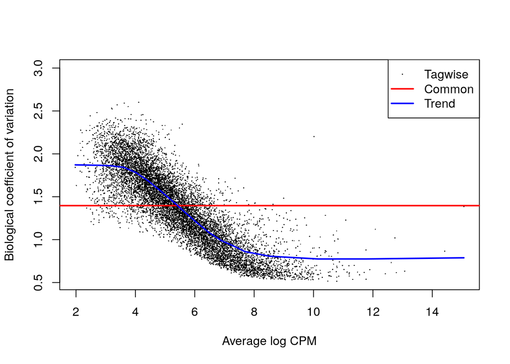

```r
# Conduct likelihood ratio tests for luts vs ctrl and show the top genes:
lrt.qfit <- glmLRT(q.fit, coef=2, contrast=contr.matrix)
sig.qfit.genes<-subset(lrt.qfit$table,(PValue < 0.05))

dispersion0 <- estimateDisp(dgel, design)
plotBCV(dispersion0)
```

```r
glmfit <- glmFit(dispersion0, design)
lrt <- glmLRT(glmfit, contrast=contr.matrix)
topTags(lrt)
```

```
## Coefficient:  1*CTRL -1*LUTS
##                  logFC    logCPM        LR      PValue       FDR
## SLC2A4RG     -3.764738  4.984411 10.241734 0.001372984 0.9999253
## UBE2J2        3.260796  5.215713  8.941904 0.002787021 0.9999253
## TP73-AS1     -2.510356  5.040878  8.508372 0.003535161 0.9999253
## HBB          -5.034840 10.017600  8.033398 0.004592261 0.9999253
## CENPC        -2.556051  5.277060  7.726368 0.005442012 0.9999253
## MIR6723      -1.763181  7.053480  7.436326 0.006392025 0.9999253
## NCDN          2.280516  6.271203  7.070340 0.007837038 0.9999253
## RABGEF1      -1.772531  6.355901  6.926854 0.008491092 0.9999253
## NMNAT2        2.310785  5.153185  6.613286 0.010122072 0.9999253
## LOC101929450 -2.998215  4.365711  6.545468 0.010515169 0.9999253
```

```r
sig.lrt.genes<-subset(lrt$table,(PValue < 0.05))
lrt.de2 <- decideTestsDGE(lrt, adjust.method="BH", p.value = 0.05)
lrt.de2tags12 <- rownames(lrt.de2)[as.logical(lrt.de2)]
tp <- topTags(lrt, n=Inf)
sum(tp$table$PValue < 0.05)
```

```
## [1] 85
```

```r
DE <- tp$table[tp$table$PValue < 0.05,]
```

# Interpretation/Conclusion of the Investigation:

The R Project for Statistical Computing. http://www.r-project.org/

Robinson, M. D., D. J. McCarthy, and G. K. Smyth. 2009. “edgeR: a Bioconductor package for differential expression analysis of digital gene expression data.” Bioinformatics 26 (1). Oxford University Press:139–40. https://doi.org/10.1093/bioinformatics/btp616.

Ritchie, M. E., B. Phipson, D. Wu, Y. Hu, C. W. Law, W. Shi, and G. K. Smyth. 2015. “limma Powers Differential Expression Analyses for RNA-Sequencing and Microarray Studies.” Nucleic Acids Res 43 (7):e47.

Law, Charity W., Yunshun Chen, Wei Shi, and Gordon K. Smyth. 2014. “Voom: precision weights unlock linear model analysis tools for RNA-seq read counts.” Genome Biology 15 (2). BioMed Central Ltd:R29+. https://doi.org/10.1186/gb-2014-15-2-r29.

L. Goff, C. Trapnell and D. Kelley (2013). “CummeRbund: Analysis, Exploration, Manipulation, and Visualization of Cufflinks High-Throughput Sequencing Data.” R package version 2.20.0.